# Algorithm to make city urban master plan

## Description

### Input data

Input - GeoJSON file with main objects, restrictions and areas for buildings The program must do next:

1. Plot boundaries – transmitted in GeoJSON format (FeatureCollection with Polygon).
2. Take into account restrictions on building density – percentage of the plot area allowed for development.
3. Take into account minimum distance between objects – for example, 10 meters between buildings.
4. Additional restrictions – presence of roads, forests, water bodies on which construction is prohibited (also transmitted in GeoJSON).

### Algorithm tasks

1. Divide the site into logical zones (e.g. residential buildings, parks, roads).
2. Place objects (buildings, roads, green areas) taking into account the specified restrictions, excluding construction in prohibited zones (roads, forests, water bodies).
3. Generate an image of the site plan.
4. Create a GeoJSON file with the coordinates of the placed objects.

[output not shown]

```
output\geo_data_2_output
```

```
                                            geometry            name  \
0  POLYGON ((-74.02 40.7, -73.99 40.7, -73.99 40....  Зона застройки
1  POLYGON ((-74.01 40.71, -74.005 40.71, -74.005...     Лесная зона
2        LINESTRING (-74.018 40.705, -73.992 40.705)          Дорога

  restriction
0         NaN
1    no_build
2    no_build
```

Before - project coordinates to local meters system for simplifying further analyze. After analyze and design the result would be exported to original coordinate system

```
                                            geometry            name  \
0  POLYGON ((-5007597.498 12718340.41, -5009521.8...  Зона застройки
1  POLYGON ((-5006940.112 12716509.035, -5007260....     Лесная зона
2  LINESTRING (-5007076.432 12717721.188, -500874...          Дорога

  restriction
0         NaN
1    no_build
2    no_build
```

```
Local bounds: [   0.            0.         4261.94656486 4482.39024274]
```

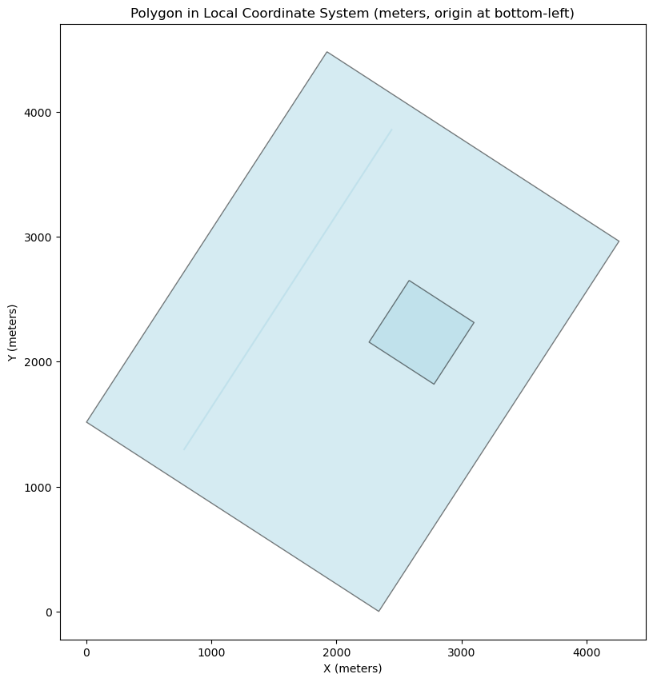

```
Back to WGS84 bounds: [-74.02   40.7   -73.99   40.718]
```

```
                                            geometry            name  \
0  POLYGON ((1924.32 4482.39, 0 1516.058, 2339.12...  Зона застройки
1  POLYGON ((2581.706 2651.015, 2261.103 2156.767...     Лесная зона
2  POLYGON ((779.68 1291.557, 779.565 1291.397, 7...          Дорога

  restriction
0         NaN
1    no_build
2    no_build
```

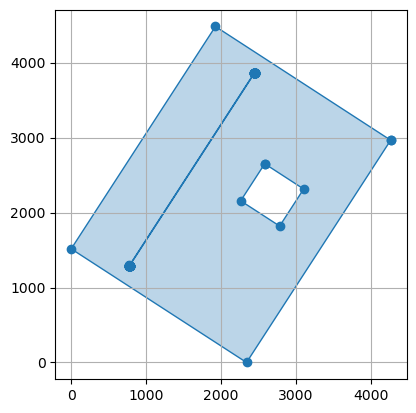

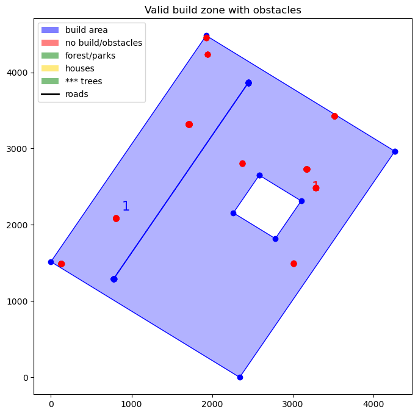

```
(<Figure size 800x800 with 1 Axes>, <Axes: >)
```

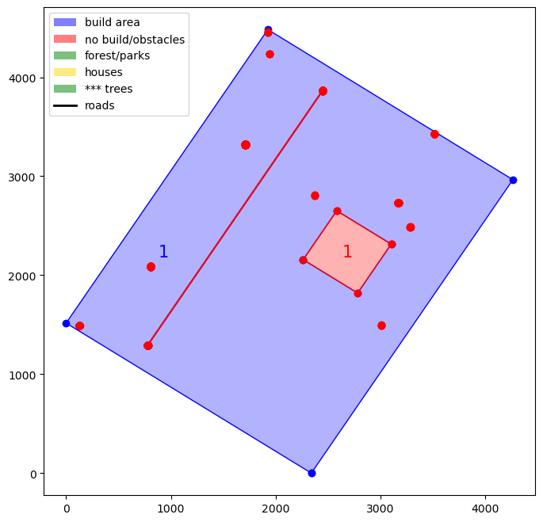

Separate territory into zones for buildings, roads and park For separation Voronoi diagram would be used

```
max_build_area:3790109.63
required_radius:172.72
house_zone_area:93721.16
n_houses_max:41
```

[output not shown]

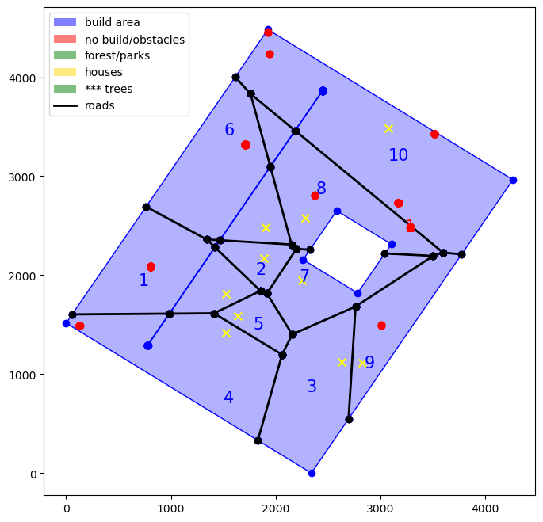

```
[[0. 0. 0. 1. 0. 1. 0. 1. 0. 0. 0. 0. 0. 0.]
 [0. 0. 1. 0. 0. 1. 1. 0. 0. 0. 0. 0. 0. 0.]
 [0. 1. 0. 0. 0. 0. 1. 0. 1. 1. 1. 0. 0. 0.]
 [1. 0. 0. 0. 0. 0. 0. 1. 0. 0. 0. 0. 0. 0.]
 [0. 0. 0. 0. 0. 1. 1. 0. 0. 1. 0. 0. 1. 0.]
 [1. 1. 0. 0. 1. 0. 1. 0. 0. 0. 0. 0. 0. 0.]
 [0. 1. 1. 0. 1. 1. 0. 0. 0. 1. 0. 0. 0. 0.]
 [1. 0. 0. 1. 0. 0. 0. 0. 0. 0. 0. 1. 0. 1.]
 [0. 0. 1. 0. 0. 0. 0. 0. 0. 0. 1. 0. 0. 0.]
 [0. 0. 1. 0. 1. 0. 1. 0. 0. 0. 1. 0. 1. 0.]
 [0. 0. 1. 0. 0. 0. 0. 0. 1. 1. 0. 0. 1. 1.]
 [0. 0. 0. 0. 0. 0. 0. 1. 0. 0. 0. 0. 0. 1.]
 [0. 0. 0. 0. 1. 0. 0. 0. 0. 1. 1. 0. 0. 1.]
 [0. 0. 0. 0. 0. 0. 0. 1. 0. 0. 1. 1. 1. 0.]]
[3. 3. 5. 2. 4. 4. 5. 4. 2. 5. 5. 2. 4. 4.]
```

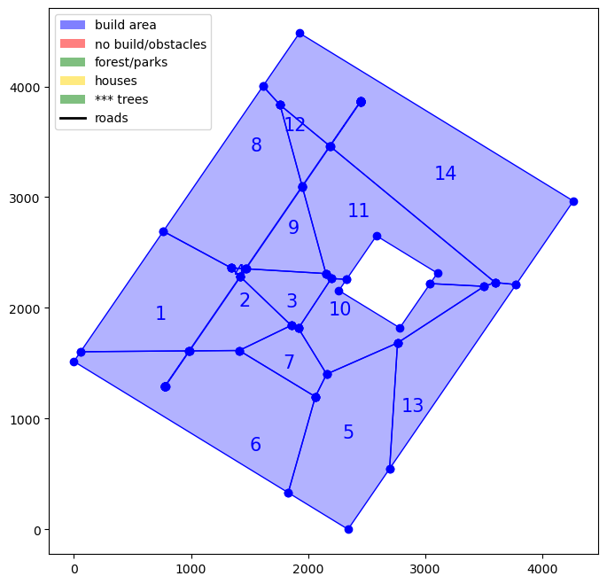

[output not shown]

```
(<Figure size 800x800 with 1 Axes>, <Axes: >)
```

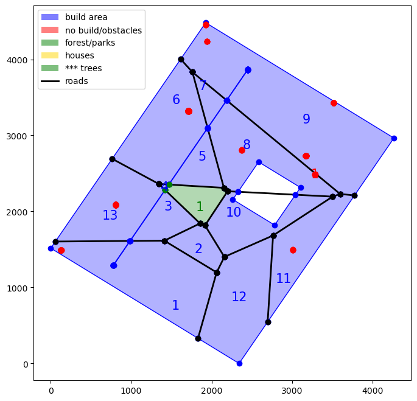

```
area for buildings except parks: 9475274.076466002,
is it enough (>3790109.6305864016)?: True
```

now lest add some syntetic obstacles in the middle of the road and try to optimize the path to go around it + take into account other obstacles we had before

```
road 0: (762.7733654775506, 2691.8700569459347) - (1341.3867675045192, 2361.2827081492187)
road constructed in 3 parts
road 1: (1341.3867675045192, 2361.2827081492187) - (1854.0422912165575, 1841.7730211657129)
road constructed in 4 parts
road 2: (1854.0422912165575, 1841.7730211657129) - (1410.440876568108, 1614.920854492154)
road constructed in 2 parts
road 3: (1410.440876568108, 1614.920854492154) - (56.93590951113703, 1603.8240170119484)
road constructed in 3 parts
road 4: (1341.3867675045192, 2361.2827081492187) - (2150.446737014106, 2309.915278019842)
road constructed in 4 parts
road 5: (2150.446737014106, 2309.915278019842) - (2196.350626325381, 2265.1643870112885)
road constructed in 2 parts
road 6: (2196.350626325381, 2265.1643870112885) - (1915.7637562177395, 1815.5454942697563)
road constructed in 2 parts
road 7: (1915.7637562177395, 1815.5454942697563) - (1854.0422912165575, 1841.7730211657129)
road constructed in 2 parts
road 8: (1828.7144415884447, 330.8115146138008) - (2060.1884690357538, 1197.6034128130345)
road constructed in 2 parts
road 9: (2060.1884690357538, 1197.6034128130345) - (2156.405195700519, 1401.6057592612972)
road constructed in 2 parts
road 10: (2156.405195700519, 1401.6057592612972) - (2761.4415204463835, 1683.4524457655054)
road constructed in 2 parts
road 11: (2761.4415204463835, 1683.4524457655054) - (2694.0133090965132, 547.2586843313632)
road constructed in 2 parts
road 12: (1410.440876568108, 1614.920854492154) - (2060.1884690357538, 1197.6034128130345)
road constructed in 2 parts
road 13: (1915.7637562177395, 1815.5454942697563) - (2156.405195700519, 1401.6057592612972)
road constructed in 2 parts
road 14: (1613.2243714863416, 4002.8373928728774) - (1759.2635832793221, 3832.5720948996304)
road constructed in 2 parts
road 15: (1759.2635832793221, 3832.5720948996304) - (2150.446737014106, 2309.915278019842)
road constructed in 4 parts
road 16: (2196.350626325381, 2265.1643870112885) - (3500.868859770157, 2194.439574758695)
road constructed in 4 parts
road 17: (3500.868859770157, 2194.439574758695) - (2761.4415204463835, 1683.4524457655054)
road constructed in 2 parts
road 18: (1759.2635832793221, 3832.5720948996304) - (3594.656434527456, 2229.072535056767)
road constructed in 4 parts
road 19: (3594.656434527456, 2229.072535056767) - (3500.868859770157, 2194.439574758695)
road constructed in 2 parts
road 20: (3594.656434527456, 2229.072535056767) - (3772.5701386823134, 2210.44787741307)
road constructed in 2 parts
```

```
(<Figure size 800x800 with 1 Axes>, <Axes: >)
```

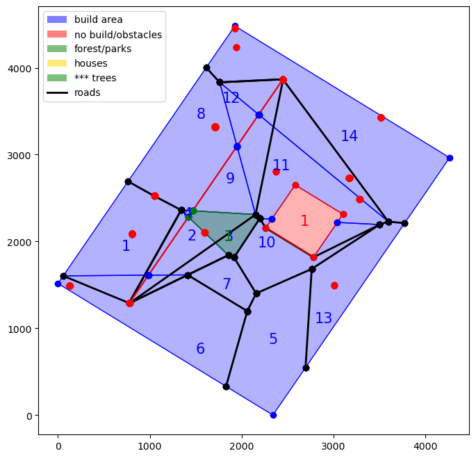

```
                                             geometry  \
0   POLYGON ((1924.32 4482.39, 0 1516.058, 2339.12...
1   POLYGON ((2581.706 2651.015, 2261.103 2156.767...
2   POLYGON ((779.68 1291.557, 779.565 1291.397, 7...
0   MULTIPOLYGON (((1924.736 4455.942, 1926.077 44...
0   POLYGON ((1341.387 2361.283, 1418.263 2283.379...
1   POLYGON ((1854.042 1841.773, 1410.441 1614.921...
2   POLYGON ((1421.14 2280.463, 1468.335 2353.223,...
3   POLYGON ((1341.387 2361.283, 1463.756 2353.513...
4   POLYGON ((2060.188 1197.603, 2156.405 1401.606...
5   POLYGON ((982.388 1611.411, 776.324 1293.733, ...
6   POLYGON ((2060.188 1197.603, 1410.441 1614.921...
7   POLYGON ((1759.264 3832.572, 1947.61 3099.446,...
8   POLYGON ((2150.447 2309.915, 1468.335 2353.223...
9   POLYGON ((1915.764 1815.545, 2196.351 2265.164...
```

[output cut: 72 more lines]

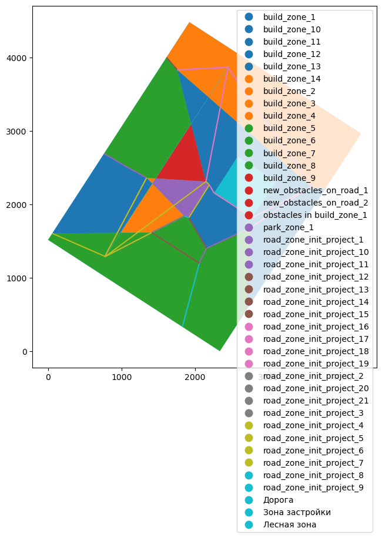

# Place objects into map - buildings, roads, green zones

taking into account restrictions

```
(<Figure size 800x800 with 1 Axes>, <Axes: >)
```

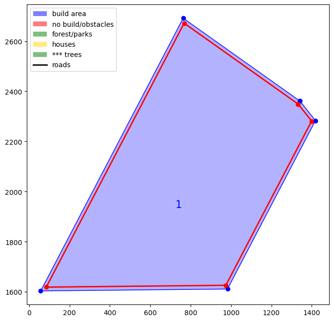

```
zone 0
poly_area:1313707.28
house radius:97.72
poly_build_area:525482.91
center_zone_area:93721.16
estimated number of centers: 6
estimated number of houses: 18
number of generated centers on grid: 10
select that are far from restrictions
number of generated centers on grid: 26
select that are far from restrictions

zone 1
poly_area:227895.49
house radius:97.72
poly_build_area:91158.20
center_zone_area:93721.16
estimated number of centers: 1
estimated number of houses: 4
number of generated centers on grid: 1
Warning: Requested 20 centers, but max possible ~13
number of generated centers on grid: 4
Could only place 4 of 20 centers due to space/restrictions

zone 2
poly_area:287234.47
house radius:97.72
poly_build_area:114893.79
center_zone_area:93721.16
estimated number of centers: 2
estimated number of houses: 4
number of generated centers on grid: 1
Could only place 1 of 2 centers due to space/restrictions
Warning: Requested 20 centers, but max possible ~16
number of generated centers on grid: 5
Could only place 5 of 20 centers due to space/restrictions

zone 3
poly_area:4467.90
house radius:97.72
```

[output cut: 103 more lines]

```

zone 12
poly_area:819879.74
house radius:97.72
poly_build_area:327951.90
center_zone_area:93721.16
estimated number of centers: 4
estimated number of houses: 11
number of generated centers on grid: 7
select that are far from restrictions
number of generated centers on grid: 24
select that are far from restrictions
Warning: Requested 227113 centers, but max possible ~13
number of generated centers on grid: 7
Could only place 7 of 227113 centers due to space/restrictions
```

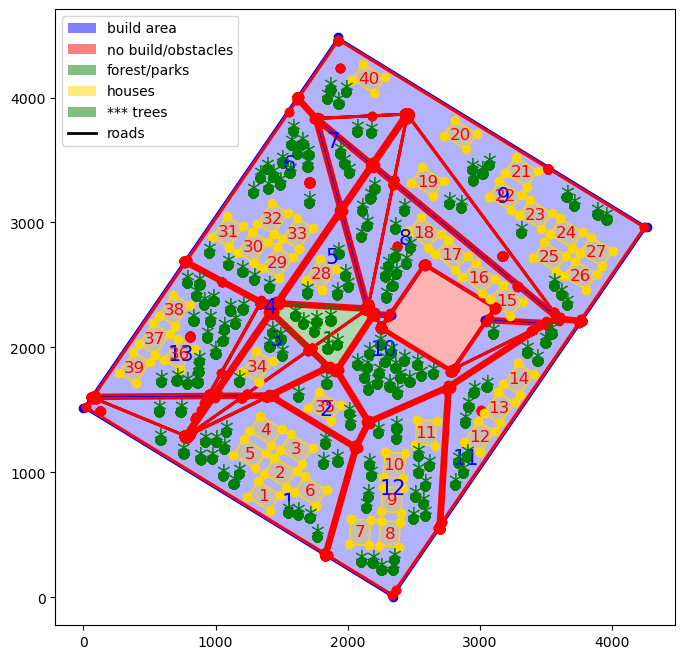

# Save and export results

```
Map saved to output\geo_data_2_output.png
```

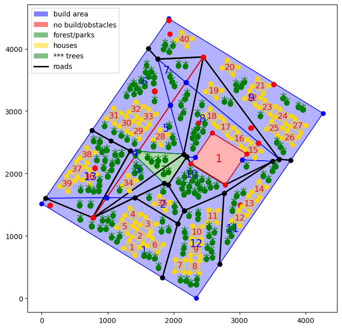

all coordinates are converted from local back to EPSG

```
                                             geometry  \
0   POLYGON ((-74.02 40.7, -73.99 40.7, -73.99 40....
1   POLYGON ((-74.01 40.71, -74.005 40.71, -74.005...
2   POLYGON ((-73.992 40.70501, -73.992 40.70501, ...
0   MULTIPOLYGON (((-74.01981 40.7001, -74.01982 4...
0   POLYGON ((-74.00221 40.7043, -74.00201 40.7049...
..                                                ...
2   POLYGON ((-74.00361 40.70768, -74.00361 40.707...
3   POLYGON ((-74.00243 40.70864, -74.00243 40.708...
4   POLYGON ((-74.00241 40.70732, -74.0024 40.7073...
5   POLYGON ((-74.00246 40.70664, -74.00246 40.706...
6   POLYGON ((-74.00188 40.70836, -74.00187 40.708...

                         name restriction
0              Зона застройки         NaN
1                 Лесная зона    no_build
2                      Дорога    no_build
0   obstacles in build_zone_1    no_build
0                build_zone_1    build_ok
..                        ...         ...
2                     trees_3    build_ok
3                     trees_4    build_ok
4                     trees_5    build_ok
5                     trees_6    build_ok
6                     trees_7    build_ok

[89 rows x 3 columns]
Exported to output\geo_data_2_output.json
```

```
Report saved to output\geo_data_2_output.html
```